# To Err is Human: Understanding Error Messages in R 😨 + 💻

Jasmine Dumas | [@jasdumas](https://twitter.com/jasdumas) | [jasdumas.github.io](http://jasdumas.github.io/)

November 6, 2016

# Relevant Quotes

> “to err is human; to forgive, divine” - Alexander Pope, “Essay on Criticism”

> “to err is human; to really screw up, you need a computer” - Internet

> “Programs must be written for people to read, and only incidentally for machines to execute.” ― Harold Abelson, Structure and Interpretation of Computer Programs

# Presentation overview

- Overview and intended audience
- Introduction
  - Humanizing mistakes
  - Feelings exercise
  - The **B.R.I.E** Method 🧀
- Common sources of error messages
  - Data types & structures
  - Data wrangling
- Additional Learning Resources
- Questions & Discussion

# Intended audience

- This presentation is intended for beginners to the R language and environment
- Those who want to overcome fears of decoding messages
- Those who want to build portable skills to asses their code and minimize downtime due to R’s *sometimes* confusing & cryptic errors.

# Introduction

# Everyone makes mistakes

- Errors (and their messages) happen to everyone, even experienced programmers.
- Learning how to solve and interpret errors will help us to write efficient and elegant code.
- Developing skills to cope with the frustration of error message will make for a more enjoyable time crafting programs.

# All the feels! | Describe your feelings about this picture

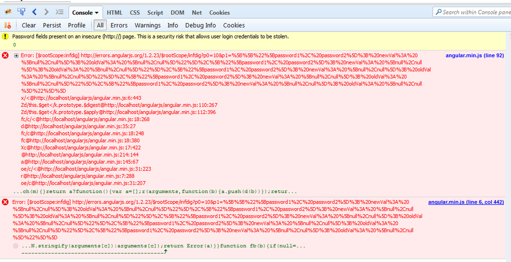

# B.R.I.E Method 🧀

- First steps in confidently approaching error messages is by following the B.R.I.E Method
  - **B**reathe and relax your mind
  - **R**e-read the error message and focus on key wording
  - **I**solate the **E**rror within your code to reduce complexity
- Hopefully this method can act as a guide to approaching and solving errors in your R code (and other programming languages as well!)

# Common Sources of Error Messages

# Data types & structures

- Many error messages start from applying the wrong method or function with a data structures.
- R base has **5** common data structures:
  - Atomic Vector: *logical, integer, double (often called numeric), and character.*
  - Matrix
  - Array
  - List
  - Data Frame

# Error #1: non-numeric argument to binary operator

```r
name_string = "Jasmine"
name_string * 2
```

```
## Error in name_string * 2: non-numeric argument to binary operator
```

- To decode this error the key statement is ‘binary operator’. Multiplication requires *two* numeric values around the * symbol.
- This error informs the user that one of the values supplied to the multiplication recipe is not a number!
- Note: A unary operator is a `+` (positive) or `-` (negative) in-front of a number.

# Error #2: invalid ‘type’ (character) of argument

```r
vec <- c(1, 2, 3, 4, 5, "hello world")
sum(vec)
```

```
## Error in sum(vec): invalid 'type' (character) of argument
```

- This error states that the character ‘type’ cannot be included in the aggregate function `sum()`. Only numeric or integer values can be summed.
- Once again this is a improper mixing of data types numeric and characters.

# Data wrangling

- Data wrangling and cleaning can take the majority of time in the data science workflow.
- Many type of errors can arise when subsetting and manipulating multi-dimensional data objects.
- With different types of packages it can be common to get flustered by confusing errors that can be function specific such as requiring an input argument to be a list instead of a data frame

# Error #3: all arguments must have the same length

```r
df <- data.frame("age" = c(32, 31, 34),
                 "pet" = c(F, T, T),
                 "name" = c("Adam", "Blake", "Anders"))
table(df$age, df$pets)
```

```
## Error in table(df$age, df$pets): all arguments must have the same length
```

- The error describes that the two supplied arguments to `table()` are not the same length which is required for cross tabulation. The spelling mistake (*pet versus pets*) actually has a length of **0** which is a mismatch from df$age which has a length **3** but the error message does not indicate that the column name was **misspelled.**

# Additional Learning Resources

- Advanced R by Hadley Wickham http://adv-r.had.co.nz/
- R-bloggers post on weird R errors http://www.r-bloggers.com/translating-weird-r-errors/

# Questions & Discussion!

[figure not shown]